# Homework #5

Brandon Güell & Dani Antos

11/10/2017

# Load in the data

```r
library(curl)
f <- curl("https://raw.githubusercontent.com/fuzzyatelin/fuzzyatelin.github.io/master/AN597_Fall17/KamilarAndCooperData.csv")
d <- read.csv(f, header = TRUE, sep = ",", stringsAsFactors = FALSE)
head(d)
```

```
##               Scientific_Name          Family          Genus      Species
## 1 Allenopithecus_nigroviridis Cercopithecidae Allenopithecus nigroviridis
## 2         Allocebus_trichotis Cercopithecidae      Allocebus    trichotis
## 3           Alouatta_belzebul        Atelidae       Alouatta     belzebul
## 4             Alouatta_caraya        Atelidae       Alouatta       caraya
## 5            Alouatta_guariba        Atelidae       Alouatta      guariba
## 6           Alouatta_palliata        Atelidae       Alouatta     palliata
##   Brain_Size_Species_Mean Brain_Size_Female_Mean   Brain_size_Ref
## 1                   58.02                  53.70 Isler et al 2008
## 2                      NA                     NA
## 3                   52.84                  51.19 Isler et al 2008
## 4                   52.63                  47.80 Isler et al 2008
## 5                   51.70                  49.08 Isler et al 2008
## 6                   49.88                  48.04 Isler et al 2008
##   Body_mass_male_mean Body_mass_female_mean Mass_Dimorphism
```

[output cut: 69 more lines]

# Linear Regression

```r
m=lm(data= d, log(HomeRange_km2) ~ log(Body_mass_female_mean))
summary(m)
```

```
##
## Call:
## lm(formula = log(HomeRange_km2) ~ log(Body_mass_female_mean),
##     data = d)
##
## Residuals:
##     Min      1Q  Median      3Q     Max
## -3.3929 -0.9433 -0.0126  1.0944  3.6826
##
## Coefficients:
##                            Estimate Std. Error t value Pr(>|t|)
## (Intercept)                -9.44123    0.67293  -14.03   <2e-16 ***
## log(Body_mass_female_mean)  1.03643    0.08488   12.21   <2e-16 ***
## ---
## Signif. codes:  0 '***' 0.001 '**' 0.01 '*' 0.05 '.' 0.1 ' ' 1
##
## Residual standard error: 1.423 on 135 degrees of freedom
##   (76 observations deleted due to missingness)
## Multiple R-squared:  0.5248, Adjusted R-squared:  0.5213
## F-statistic: 149.1 on 1 and 135 DF,  p-value: < 2.2e-16
```

## Report: β coeffiecients (slope and intercept):

```r
m$coefficients
```

```
##                (Intercept) log(Body_mass_female_mean)
##                  -9.441231                   1.036432
```

- **slope: 1.03643**
- **intercept: -9.44123**

# Use bootstrapping to sample from your data 1000 times with replacement:

- lets use the boot package

> make sure to install package “boot”

```r
library(boot)

# multiple k

# function to obtain regression weights
bs <- function(formula, data, indices) {
  d <- data[indices,] # allows boot to select sample
  fit <- lm(formula, data=d)
  return(coef(fit))
}
# bootstrapping with 1000 replications & replication
results <- boot(data= d, statistic=bs, R=1000, formula=log(HomeRange_km2) ~ log(Body_mass_female_mean))

# view results
results
```

```
##
## ORDINARY NONPARAMETRIC BOOTSTRAP
##
##
## Call:
## boot(data = d, statistic = bs, R = 1000, formula = log(HomeRange_km2) ~
##     log(Body_mass_female_mean))
##
##
## Bootstrap Statistics :
##      original      bias    std. error
## t1* -9.441231 -0.03597400  0.59214343
## t2*  1.036432  0.00392968  0.07603657
```

> Just for fun:

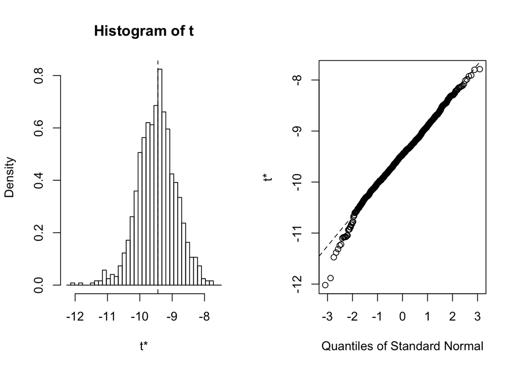

```r
plot(results, index=1) # intercept
```

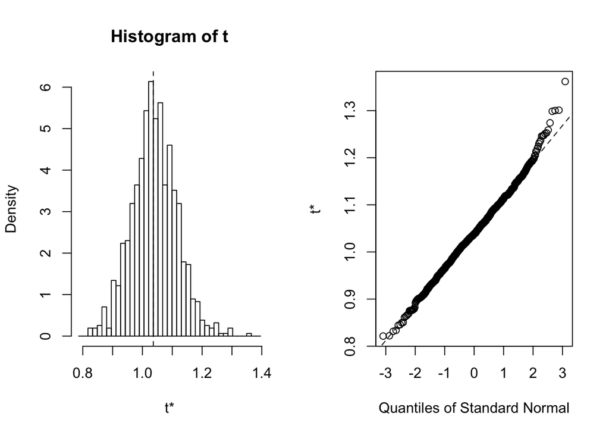

```r
plot(results, index=2) # log(body mass femaile mean)
```

## Standard Error of Bootstrap:

```r
results
```

```
##
## ORDINARY NONPARAMETRIC BOOTSTRAP
##
##
## Call:
## boot(data = d, statistic = bs, R = 1000, formula = log(HomeRange_km2) ~
##     log(Body_mass_female_mean))
##
##
## Bootstrap Statistics :
##      original      bias    std. error
## t1* -9.441231 -0.03597400  0.59214343
## t2*  1.036432  0.00392968  0.07603657
```

## Confidence Intervals of Bootstrap:

```r
# get 95% confidence intervals for bootstrap
boot.ci(results, type="bca", index=1) # intercept
```

```
## BOOTSTRAP CONFIDENCE INTERVAL CALCULATIONS
## Based on 1000 bootstrap replicates
##
## CALL :
## boot.ci(boot.out = results, type = "bca", index = 1)
##
## Intervals :
## Level       BCa
## 95%   (-10.604,  -8.297 )
## Calculations and Intervals on Original Scale
```

```r
boot.ci(results, type="bca", index=2) # log(body mass femaile mean)
```

```
## BOOTSTRAP CONFIDENCE INTERVAL CALCULATIONS
## Based on 1000 bootstrap replicates
##
## CALL :
## boot.ci(boot.out = results, type = "bca", index = 2)
##
## Intervals :
## Level       BCa
## 95%   ( 0.894,  1.192 )
## Calculations and Intervals on Original Scale
```

## Comparisons of Standard Errors:

```r
summary(m)
```

```
##
## Call:
## lm(formula = log(HomeRange_km2) ~ log(Body_mass_female_mean),
##     data = d)
##
## Residuals:
##     Min      1Q  Median      3Q     Max
## -3.3929 -0.9433 -0.0126  1.0944  3.6826
##
## Coefficients:
##                            Estimate Std. Error t value Pr(>|t|)
## (Intercept)                -9.44123    0.67293  -14.03   <2e-16 ***
## log(Body_mass_female_mean)  1.03643    0.08488   12.21   <2e-16 ***
## ---
## Signif. codes:  0 '***' 0.001 '**' 0.01 '*' 0.05 '.' 0.1 ' ' 1
##
## Residual standard error: 1.423 on 135 degrees of freedom
##   (76 observations deleted due to missingness)
## Multiple R-squared:  0.5248, Adjusted R-squared:  0.5213
## F-statistic: 149.1 on 1 and 135 DF,  p-value: < 2.2e-16
```

- **intercept: 0.67293**
- **log(body mass femaile mean): 0.08488**

> VS. the Standard Error of Bootstrap:

```r
results
```

```
##
## ORDINARY NONPARAMETRIC BOOTSTRAP
##
##
## Call:
## boot(data = d, statistic = bs, R = 1000, formula = log(HomeRange_km2) ~
##     log(Body_mass_female_mean))
##
##
## Bootstrap Statistics :
##      original      bias    std. error
## t1* -9.441231 -0.03597400  0.59214343
## t2*  1.036432  0.00392968  0.07603657
```

To us, these seem incredibly similar.

## Comparisons of Confidence Intervals:

```r
confint(m, level = 0.95)
```

```
##                                  2.5 %    97.5 %
## (Intercept)                -10.7720889 -8.110374
## log(Body_mass_female_mean)   0.8685707  1.204292
```

- **intercept: -10.7720889 -8.110374**
- **log(body mass femaile mean): 0.8685707 1.204292**

> VS. the Confidence Interval of Bootstrap:

```r
# get 95% confidence intervals for bootstrap
boot.ci(results, type="bca", index=1) # intercept
```

```
## BOOTSTRAP CONFIDENCE INTERVAL CALCULATIONS
## Based on 1000 bootstrap replicates
##
## CALL :
## boot.ci(boot.out = results, type = "bca", index = 1)
##
## Intervals :
## Level       BCa
## 95%   (-10.604,  -8.297 )
## Calculations and Intervals on Original Scale
```

```r
boot.ci(results, type="bca", index=2) # log(body mass femaile mean)
```

```
## BOOTSTRAP CONFIDENCE INTERVAL CALCULATIONS
## Based on 1000 bootstrap replicates
##
## CALL :
## boot.ci(boot.out = results, type = "bca", index = 2)
##
## Intervals :
## Level       BCa
## 95%   ( 0.894,  1.192 )
## Calculations and Intervals on Original Scale
```

Again, to us, these seem not different.

# Extra Credit

> Write a FUNCTION that takes as its arguments a dataframe, “d”, a linear model, “m” (as a character string, e.g., “logHR~logBM”), a user-defined confidence interval level, “conf.level” (with default = 0.95), and a number of bootstrap replicates, “n” (with default = 1000). Your function should return a dataframe that includes: beta coefficient names; beta coefficients, standard errors, and upper and lower CI limits for the linear model based on your entire dataset; and mean beta coefficient estimates, SEs, and CI limits for those coefficients based on your bootstrap.

```r
b.guell.d.antos <- function(d, m, conf.level = 0.95, n = 1000)
{

# model
m = lm(data=d, m)

# names
BCoeffNames = names(m$coefficients)

# beta coefficients
data_coeff = coef(summary(m))[, 1]

# data SE and CI
data_SE = coef(summary(m))[, "Std. Error"]
data_CI= confint(m)
data_CI

# Bootstrap stuff:

 library(boot)
  bs <- function(formula, data, indices) {
  d <- data[indices,] # allows boot to select sample
  fit <- lm(formula, data=d)
  return(coef(fit))
  }

# bootstrapping with 1000 replications & replication
results <- boot(data= d, statistic= bs, R=1000, formula= m)

# Bootsrap coefficients
mean_B0= mean(results$t[,1])
mean_B0
mean_B1= mean(results$t[,2])
mean_B1

BootCoeff = c(mean_B0, mean_B1)
BootCoeff


# Bootsrap SE and CI
SE_func <- function(x) {
      sd(x)/sqrt(length(x))
}

BootSE_B0 = SE_func(results$t[,1])
BootSE_B0

BootSE_B1 = SE_func(results$t[,2])
BootSE_B1

BootSE = c(BootSE_B0, BootSE_B1) #must make them into a vector so that it splits in the dataframe nicely..

# confidence intervals
BootB0CI = boot.ci(results, type="bca", index=1) # intercept
BootB0CI = BootB0CI$bca[,4:5]
BootB0CI

BootB1CI = boot.ci(results, type="bca", index=2) # log(body mass femaile mean)
BootB1CI = BootB1CI$bca[,4:5]
BootB1CI

# Holy shit... difficult but got it in the right format! yay!
BootCI2.5 = c(BootB0CI[1], BootB1CI[1])
BootCI97.5 = c( BootB0CI[2], BootB1CI[2])
BootCI = cbind(BootCI2.5, BootCI97.5)
BootCI

  spitout <- data.frame(
     BCoeffNames = BCoeffNames,
         data_coeff = data_coeff,
     data_SE = data_SE,
         data_CI = data_CI,

     BootCoeff = BootCoeff,
         BootSE = BootSE,
         BootCI) # dont need to name it here because its a dataframe already)

  rownames(spitout) <- NULL # get rid of excess row names...

    return(spitout)
  }
```

# Extra Extra Credit

> Graph each beta value from the linear model and its corresponding mean value, lower CI and upper CI from a bootstrap as a function of number of bootstraps from 10 to 200 by 10s. HINT: the beta value from the linear model will be the same for all bootstraps and the mean beta value may not differ that much!